# Simulation Study with Splatter

### Brief Description

In this notebook, we document the generation of the simulated single-cell dataset from a trajectory using Splatter (Zappia et al., Genome Biology, 2017). We use this simulated data to demonstrate the efficacy of Capybara to classify discrete, hybrid, unknown cells, and unknown progenitors. For simulation details, please refer to the Splatter paper (https://genomebiology.biomedcentral.com/articles/10.1186/s13059-017-1305-0). For details of Capybara cell-type classification, please refer to the Capybara paper here (https://www.sciencedirect.com/science/article/pii/S1934590922000996?dgcid=coauthor).

### Load packages

```r
library(splatter)
library(Capybara)
library(scater)
library(mixdist)
library(MASS)
require(pastecs)
```

### Load source functions

```r
### https://math.stackexchange.com/questions/453113/how-to-merge-two-gaussians
calculate.params <- function(fitted.params) {
  mu.est <- sum(fitted.params$parameters$mu * fitted.params$parameters$pi)
  var.num <- (fitted.params$parameters$sigma)^2
  var.est <- sum(var.num * (fitted.params$parameters$pi)^2)

  return(list(mu.est, var.est))
}

model.estimation <- function(background) {
  d <- density(background)
  his <- hist(background, breaks = 100)

  df <- data.frame(mid=his$mids, cou=his$counts)
  ts_y <- ts(d$y)
  tp <- turnpoints(ts_y)
  guemea <- d$x[tp$peaks]
  guesig <- rep((max(df$mid) - min(df$mid))/4, length(guemea))

  guedis <- "norm"
  fitpro <- mix(as.mixdata(df), mixparam(mu=guemea, sigma=guesig))

  return(fitpro)
}

calculate.deviance.p.val <- function(deviance.df, centers.smu) {
  cell.types <- ncol(deviance.df) - 1
  sd.est <- (1/cell.types)/(cell.types - 1)
  deviance.df$p.val.single <- pnorm(deviance.df$total.deviance, mean = centers.smu$single.center, sd = sd.est)
  deviance.df$p.val.multi <- pnorm(deviance.df$total.deviance, mean = centers.smu$multi.center, sd = sd.est)
  deviance.df$p.val.unknown <- pnorm(deviance.df$total.deviance, mean = centers.smu$unknown.center, sd = sd.est)

  return(deviance.df)
}

calculate.deviance <- function(qp.test.mtx) {
  cell.types <- ncol(qp.test.mtx) - 2
  deviance.from.all <- abs(qp.test.mtx[,c(1:cell.types)] - 1/cell.types)
  deviance.from.all$total.deviance <- rowSums(deviance.from.all)

  return(deviance.from.all)
}

get.thresholds <- function(qp.test.mtx) {
  cell.types <- ncol(qp.test.mtx) - 2
  exp.score <- 1/cell.types
  ## single id thresholds
  single.id.th.top <- (1-exp.score) + (exp.score * (cell.types - 1))
  if (cell.types >= 3) {
    single.id.th.bottom <- (1/2-exp.score) * 2 + (exp.score * (cell.types - 2))
  } else {
    print("No Solid Evidence for Multi-ID! Check the QP scores for continuous measure!")
    single.id.th.bottom <- single.id.th.top
  }

  ## multi id thresholds
  multi.id.th.top <- (1/2-exp.score) * 2 + (exp.score * (cell.types - 2))
  if (cell.types > 3) {
    multi.id.th.bottom <- (1/3-exp.score) * 3 + (exp.score * (cell.types - 3))
  } else {
    multi.id.th.bottom <- multi.id.th.top
  }

  ## Unknown thresholds
  unknown.center <- 0

  return(list(single.center = mean(c(single.id.th.top)),
              multi.center = mean(c(multi.id.th.top, multi.id.th.bottom)),
              unknown.center = unknown.center))
}
```

### Simulation with Splatter

#### Parameter Setup

Here we will use the original parameters suggested by Splatter. We design the cell population to originate from a progenitor state (P1) bifurcating toward two discrete states (E1: End State #1; P2: Progenitor State #2). P2 progenitor cells bifurcate further toward end states #2 and #3 (E2 and E3, respectively).

```r
params <- newSplatParams(batchCells = 6000,
                         nGenes = 8000,
                         group.prob = c(0.25, 0.25, 0.25, 0.25),
                         path.from = c(0, 0, 2, 2),
                         path.nSteps = c(100, 100, 100, 100),
                         de.prob = 0.5,
                         de.facLoc = 0.3,
                         de.facScale = 0.6,
                         seed = 10)
params
```

```
A Params object of class SplatParams
Parameters can be (estimable) or [not estimable], 'Default' or  'NOT DEFAULT'
Secondary parameters are usually set during simulation

Global:
(GENES)  (CELLS)   [SEED]
   8000     6000       10

29 additional parameters

Batches:
    [BATCHES]  [BATCH CELLS]     [Location]        [Scale]       [Remove]
            1           6000            0.1            0.1          FALSE

Mean:
 (Rate)  (Shape)
    0.3      0.6

Library size:
(Location)     (Scale)      (Norm)
        11         0.2       FALSE

Exprs outliers:
(Probability)     (Location)        (Scale)
         0.05              4            0.5

Groups:
              [GROUPS]           [GROUP PROBS]
                     4  0.25, 0.25, 0.25, 0.25

Diff expr:
[PROBABILITY]    [Down Prob]     [LOCATION]        [SCALE]
          0.5            0.5            0.3            0.6

BCV:
(Common Disp)          (DoF)
          0.1             60

Dropout:
    [Type]  (Midpoint)     (Shape)
      none           0          -1

Paths:
            [FROM]             [STEPS]              [Skew]        [Non-linear]      [Sigma Factor]
        0, 0, 2, 2  100, 100, 100, 100                 0.5                 0.1                 0.8
```

#### Simulate the path data

1. Here we will use the above parameters to simulate the data and plot on a PCA components plot.

```r
sim.paths <- splatSimulate(params = params, method = "path")
```

```
Getting parameters...
Creating simulation object...
Simulating library sizes...
Simulating gene means...
Simulating path endpoints...
Simulating path steps...
Simulating BCV...
Simulating counts...
Simulating dropout (if needed)...
Sparsifying assays...
Automatically converting to sparse matrices, threshold = 0.95
Skipping 'BatchCellMeans': estimated sparse size 1.5 * dense matrix
Skipping 'BaseCellMeans': estimated sparse size 1.5 * dense matrix
Skipping 'BCV': estimated sparse size 1.5 * dense matrix
Skipping 'CellMeans': estimated sparse size 1.49 * dense matrix
Skipping 'TrueCounts': estimated sparse size 1.72 * dense matrix
Skipping 'counts': estimated sparse size 1.72 * dense matrix
Done!
```

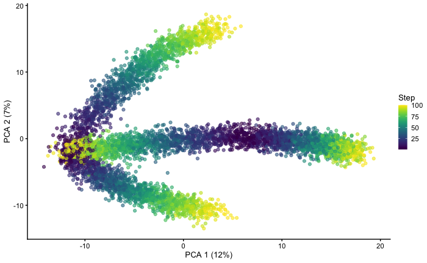

```r
sim.paths <- logNormCounts(sim.paths)
sim.paths <- runPCA(sim.paths)
plotPCA(sim.paths, colour_by = "Step")
```

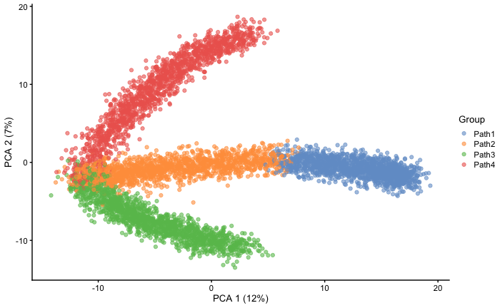

```r
plotPCA(sim.paths, colour_by = "Group")
```

2. Assess the meta data

```r
col.dt.path <- as.data.frame(colData(sim.paths))
head(col.dt.path)
```

|  | Cell | Batch | Group | ExpLibSize | Step | sizeFactor |
| --- | --- | --- | --- | --- | --- | --- |
| Cell1 | Cell1 | Batch1 | Path4 | 65650.67 | 1 | 1.082416 |
| Cell2 | Cell2 | Batch1 | Path3 | 62755.72 | 35 | 1.029743 |
| Cell3 | Cell3 | Batch1 | Path3 | 68094.48 | 85 | 1.105655 |
| Cell4 | Cell4 | Batch1 | Path4 | 71871.83 | 14 | 1.181173 |
| Cell5 | Cell5 | Batch1 | Path2 | 72959.31 | 16 | 1.200987 |
| Cell6 | Cell6 | Batch1 | Path2 | 61239.54 | 32 | 1.005799 |

3. Here, we subset the groups in preparation for Capybara processing. We construct the reference using three cell populations, including E1, P2 and E2. The differentiated cell populations are defined as within 5% variability of the maximum pseudotime. We take a look at the cell groups, including differentiated fates, progenitor state (P1), and the intermediate state between P2 and E2.

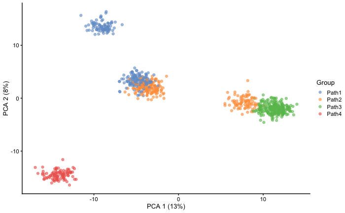

```r
cells.diff.names <- rownames(col.dt.path)[which(col.dt.path$Step >= 95)]
cells.p1.p2.ori <- rownames(col.dt.path)[which(col.dt.path$Step <= 10 & (col.dt.path$Group %in% c("Path1", "Path2")))]
cells.p2.p3.intermed <- rownames(col.dt.path)[which(col.dt.path$Step <= 55 & col.dt.path$Step > 45 & (col.dt.path$Group %in% c("Path3")))]
sim.paths.sub <- sim.paths[,c(cells.diff.names, cells.p1.p2.ori, cells.p2.p3.intermed)]
sim.paths.sub <- logNormCounts(sim.paths.sub)
sim.paths.sub <- runPCA(sim.paths.sub)
plotPCA(sim.paths.sub, colour_by = "Group")
```

### Capybara

#### Get Counts

Here we extract counts from the SingleCellExperiment object and label the different states.

```r
count.sim.path <- counts(sim.paths.sub)
col.path.sub <- as.data.frame(colData(sim.paths.sub))
col.path.sub$label[which(col.path.sub$Step <= 55 & col.path.sub$Step > 45)] <- "P3.Intermed"
col.path.sub$label[which(col.path.sub$Step <= 10)] <- "P1.P2.Origin"
col.path.sub$label[which(col.path.sub$Step >= 95)] <- paste0(col.path.sub$Group[which(col.path.sub$Step >= 95)], ".Term")
```

#### Reference Construction

```r
col.dt.path.sub.term.ori <- col.path.sub[-which(col.path.sub$label %in% c("P1.P2.Origin", "P3.Intermed", "Path4.Term")), ]
```

2. Using the Metadata above with the counts data, we construct the high-resolution reference.

```r
ref.dt.path <- construct.high.res.reference(count.sim.path, col.dt.path.sub.term.ori, "label")
ref.sc.path <- ref.dt.path[[1]]
ref.meta.path <- ref.dt.path[[2]]
ref.df.path <- ref.dt.path[[3]]
```

#### Test Set Construction

Here we generate a test set for this dataset using the remaining cells that were not included in the reference.

```r
test.remaining.cells.path <- setdiff(rownames(col.path.sub), ref.dt.path[[2]]$cell.bc)
test.count.set.path <- count.sim.path[,test.remaining.cells.path]
```

#### Run Quadratic Programming

```r
# Measure cell identity in the reference dataset as a background
single.round.QP.analysis(ref.df.path, ref.sc.path, n.cores = 2, save.to.path = "~/Desktop/Reproducibility/Figure 1/", save.to.filename = "01_simulated_data_reference", force.eq = 1, unix.par = TRUE)

# Measure cell identity in the query dataset
single.round.QP.analysis(ref.df.path, test.count.set.path, n.cores = 2, save.to.path = "~/Desktop/Reproducibility/Figure 1/", save.to.filename = "01_simulated_data_sample", unix.par = TRUE, force.eq = 1)
```

#### Empirical p-value calculation

```r
# Read in background and testing identity scores
background.mtx <- read.csv("~/Desktop/Reproducibility/Figure 1/01_simulated_data_reference_scale.csv", header = T, row.names = 1, stringsAsFactors = F)
mtx.test <- read.csv("~/Desktop/Reproducibility/Figure 1/01_simulated_data_sample_scale.csv", header = T, row.names = 1, stringsAsFactors = F)

col.sub <- ncol(background.mtx) - 2

# Conduct reference randomization to get empirical p-value matrix
ref.perc.list <- percentage.calc(background.mtx[,c(1:col.sub)], background.mtx[,c(1:col.sub)])
# Conduct test randomization to get empirical p-value matrix
perc.list <- percentage.calc(as.matrix(mtx.test[,c(1:col.sub)]), as.matrix(background.mtx[,c(1:col.sub)]))
```

#### Initial Classification

Here we perform initial classification based on the quadratic programming metrics: deviance, error, and lagrangian multipliers. Deviance the main metric used to distinguish unknown cells from discrete and hybrid cells. Error and Lagrangian multipliers are used to further distinguish the unknown terminal cell identities from unknown progenitors.

1. Calculate Deviance and background

```r
deviance.from.all <- calculate.deviance(mtx.test)
centers.diff.id <- get.thresholds(mtx.test)
deviance.from.all <- calculate.deviance.p.val(deviance.from.all, centers.diff.id)
```

2. Compute Error and Lagrangian Multiplier Distribution

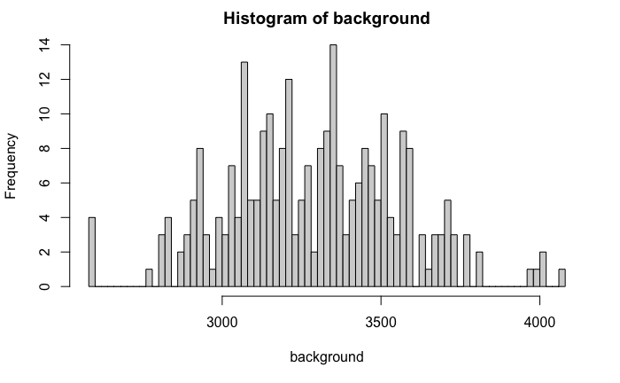

```r
error.all.new <- mtx.test[,c(4,5)]
model.fit.err <- model.estimation(background.mtx$Error)
```

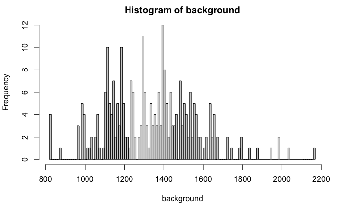

```r
model.fit.lm <- model.estimation(background.mtx$Lagrangian)
```

```r
err.params <- calculate.params(model.fit.err)
lm.params <- calculate.params(model.fit.lm)

error.all.new$p.values.lm.mode <- pnorm(error.all.new$Lagrangian, mean = lm.params[[1]], sd = sqrt(lm.params[[2]]), lower.tail = F)
error.all.new$p.values.lm.lower <- pnorm(error.all.new$Lagrangian,  mean = lm.params[[1]], sd = sqrt(lm.params[[2]]), lower.tail = T)
error.all.new$p.values <- pnorm(error.all.new$Error,  mean = err.params[[1]], sd = sqrt(err.params[[2]]), lower.tail = F)
```

3. Based on deviance, we initially classify cells as unknown, discrete, or hybrid.

```r
init.class <- data.frame(cell.bc = rownames(deviance.from.all), init.class = "Unknown", stringsAsFactors = F)
rownames(init.class) <- init.class$cell.bc
#classification.path[rownames(error.path.all[which(error.path.all$deviance < 0.5), ]), "new.classification.4"] <- "Unknown_unknown_prog"
init.class[rownames(deviance.from.all[which(deviance.from.all$p.val.single >= 0.05), ]), "init.class"] <- "Single-ID"
init.class[rownames(deviance.from.all[which(deviance.from.all$p.val.multi > 0.05 & deviance.from.all$p.val.single < 0.01), ]), "init.class"] <- "Multi_ID"
init.class[rownames(deviance.from.all[which(deviance.from.all$p.val.unknown > 0 & deviance.from.all$p.val.multi < 0.05 & deviance.from.all$p.val.single <= 0.05), ]), "init.class"] <- "Unknown"
```

4. Further distinction unknown cells.

Note: use this analysis with caution as we could not distinguish unknown terminal cell identities from unknown progenitors with 100% accuracy.

```r
### further characterization
unknown.current <- rownames(init.class[which(init.class$init.class == "Unknown"), ])
init.class[intersect(unknown.current, rownames(error.all.new[which(error.all.new$p.values >= 0.05),])), "init.class"] <- "Unknown.Progenitor"
```

#### Binarization and Classification

1. We generate the binarization matrix so that unknown cells are labelled 0, unknown progenitors -1, and known cell types labelled 1.

```r
# Binarization of inference results
bin.count <- binarization.mann.whitney(mtx = mtx.test[,c(1:col.sub)], ref.perc.ls = ref.perc.list, ref.meta = ref.meta.path, perc.ls = perc.list, init.class = init.class)
```

2. Classification based on this binary count matrix

```r
classification.path <- binary.to.classification(bin.count[,c(1:col.sub)])
rownames(classification.path) <- classification.path$barcode
```

### Compare classification

1. We compare our classification with the original label. First, we add the actual labels into the same data frame.

```r
classification.path$actual <- col.path.sub[rownames(classification.path), "label"]
```

2. Construct the percentage agreement matrix for heatmap plotting

```r
rslt <- table(classification.path$call, classification.path$actual)
rslt <- as.data.frame(apply(rslt, 2, function(x) round(x * 100/sum(x), digits = 3)))
rownames(rslt) <- paste0("Capy.", rownames(rslt))
colnames(rslt) <- paste0("Actual.", colnames(rslt))
rslt$capy <- rownames(rslt)
rslt.stk <- reshape2::melt(rslt)
```

3. Plot heatmaps with ggplot

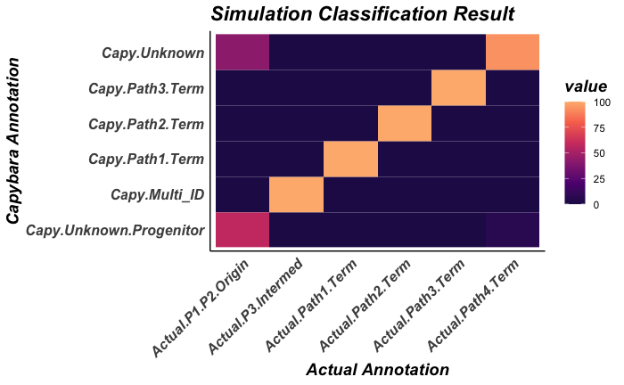

```r
rslt.stk$capy <- factor(rslt.stk$capy, levels = c("Capy.Unknown.Progenitor", "Capy.Multi_ID",
                                                  "Capy.Path1.Term", "Capy.Path2.Term", "Capy.Path3.Term",
                                                  "Capy.Unknown"), ordered = T)
rslt.stk$variable <- factor(rslt.stk$variable, levels = c("Actual.P1.P2.Origin", "Actual.P3.Intermed",
                                                  "Actual.Path1.Term", "Actual.Path2.Term", "Actual.Path3.Term",
                                                  "Actual.Path4.Term"), ordered = T)
ggplot(rslt.stk, aes(x = variable, y = capy, fill = value)) +
  geom_tile() +
  scale_fill_viridis_c(begin = 0.15, end = 0.85, option = "A") +
  labs(x = "Actual Annotation", y = "Capybara Annotation") +
  ggtitle("Simulation Classification Result") +
  theme(legend.position="right",
        axis.text.x = element_text(face = "bold.italic", size = 12, angle = 45, hjust = 1),
        axis.text.y = element_text(face = "bold.italic", size = 12),
        axis.title = element_text(face = "bold.italic", size = 14),
        panel.grid.major = element_blank(),
        panel.grid.minor = element_blank(),
        panel.background = element_blank(),
        title = element_text(face = "bold.italic", size = 14),
        axis.line = element_line(colour = "black", size = 0.5),
        axis.ticks = element_blank())
```